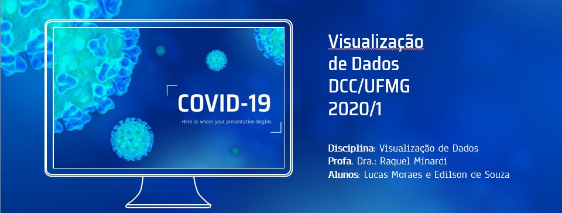

# Visualização de Dados - DCC/UFMG 2020/1 - Projeto Final

**Disciplina**: Visualização de Dados  
**Profa. Dra.**: Raquel Minardi  
**Alunos**: Lucas Moraes e Edilson de Souza

Contatos:

moraes.lsantos@gmail.com

edilson.souza@gmail.com

### **“Não podemos dizer isso em voz alta ou clara o suficiente ou com frequência suficiente: Todos os países ainda podem mudar o curso desta pandemia.”**

## **1. Proposta de Projeto**

Estudos relacionados a pandemia COVID-19 tem no atual momento extrema relevância nos aspectos sociais, econômicos e de saúde pública que a situação impõe a sociedade mundial.

Cientistas no mundo todo buscam compreender a cada dia o mecanismo de propagação do vírus na intenção de encontrar medicamentos, ou ainda uma vacina, eficiente. Dentre algumas candidatas a vacina (em estágio avançado de testes clínicos), podemos citar as desenvolvidas pela Moderna/NIAID (EUA), Sinovac (China) e Oxford/AstraZeneca (Reino Unido) estas últimas estando na terceira fase, ambas sendo testadas no Brasil.

Apesar da alta visibilidade e contingente de profissionais especializados tratando o tema, não é possível encontrar plataformas de visualização de dados que forneçam uma análise sistêmica, além de se observar um viés claro para reporte dos números absolutos de novos casos e mortes.

Dentre os mais renomados sites de divulgação de informações relativas à COVID-19 destaca-se o da Universidade John Hopkins (EUA) e o site mantido pela Universidade de Oxford (RU), Our World in Data. Em ambos podemos encontrar visualizações com grande foco nos números absolutos e com poucas correlações entre as informações publicadas, como exemplificado na figura abaixo.

[figure not shown]

Nessa linha, o presente trabalho busca integrar visualmente e correlacionar as informações disponíveis na base de dados do Our World in Data, uma vez que a mesma apresenta uma abrangência de informações maior que as demais analisadas, sendo utilizadas como fonte de informações tanto para pesquisa quanto para ensino em renomadas universidades como Stanford, Harvard e MIT, além da própria Universidade de Oxford, provedora dos dados deste projeto.

Com o trabalho, pretendemos apresentar uma ferramenta para visualização dos dados relacionados a pandemia de COVID-19 que possibilite a análise de outras informações em relação ao comportamento da doença no mundo, que outras plataformas disponíveis atualmente não abarcam.

Análises, como as elencadas abaixo, não são facilmente possibilitadas por grande parte das visualizações disponíveis na web, sendo estes os desafios que o presente trabalho pretende responder:

1. Como o número de novos casos evolui, com base no rigor das políticas de isolamento implementadas por cada país?
2. Como a velocidade de aplicação de testes tem influenciado na contenção da doença?
3. A população socialmente vulnerável está sendo mais afetada?
4. Existem outros agrupamentos ainda não explorados suficientemente? (etnia, sexo, etc...)
5. É possível elaborar visualizações de fácil entendimento que reflitam melhor a situação de cada país?
6. É possível explicar causas de aceleração ou desaceleração de propagação do vírus com os dados coletados?

## 2. Base de Dados

A base de dados a ser utilizada é a [Our World in Data](https://github.com/owid/covid-19-data/tree/master/public/data) </li> COVID-19 dataset e consta de dados atualizados diariamente sobre a pandemia dentre eles:

- Número de novos casos;
- Número de casos por milhão;
- Número de mortes;
- Número de mortes por milhão;
- Número total de testes;
- Indice Stringency (Oxford);
- Idade média;
- Percentual da população acima de 65 anos;
- PIB per capita;
- População com diabetes;
- População com doenças cardiovasculares </ul>

A lista completa de attributos segue abaixo:

```python
#Import Libraries
import os
import csv

import numpy as np
import pandas as pd
import seaborn as sn
import matplotlib.pyplot as plt
from matplotlib import dates as mpl_dates

#Import COVID-19 Dataset
df = pd.read_csv("https://raw.githubusercontent.com/owid/covid-19-data/master/public/data/owid-covid-data.csv")
df['date'] = pd.to_datetime(df['date'])
df['total_cases'] = pd.to_numeric(df['total_cases'], downcast="float")
df.info()
```

```
<class 'pandas.core.frame.DataFrame'>
RangeIndex: 52222 entries, 0 to 52221
Data columns (total 41 columns):
 #   Column                           Non-Null Count  Dtype
---  ------                           --------------  -----
 0   iso_code                         51923 non-null  object
 1   continent                        51624 non-null  object
 2   location                         52222 non-null  object
 3   date                             52222 non-null  datetime64[ns]
 4   total_cases                      48615 non-null  float32
 5   new_cases                        51338 non-null  float64
 6   new_cases_smoothed               50550 non-null  float64
 7   total_deaths                     39750 non-null  float64
 8   new_deaths                       51338 non-null  float64
 9   new_deaths_smoothed              50550 non-null  float64
```

[output cut: 33 more lines]

Segue abaixo uma amostra dos dados utilizados:

```python
#EDA
df.describe()
```

|  | total_cases | new_cases | new_cases_smoothed | total_deaths | new_deaths | new_deaths_smoothed | total_cases_per_million | new_cases_per_million | new_cases_smoothed_per_million | total_deaths_per_million | new_deaths_per_million | new_deaths_smoothed_per_million | total_tests | new_tests | total_tests_per_thousand | new_tests_per_thousand | new_tests_smoothed | new_tests_smoothed_per_thousand | tests_per_case | positive_rate | stringency_index | population | population_density | median_age | aged_65_older | aged_70_older | gdp_per_capita | extreme_poverty | cardiovasc_death_rate | … |
| --- | --- | --- | --- | --- | --- | --- | --- | --- | --- | --- | --- | --- | --- | --- | --- | --- | --- | --- | --- | --- | --- | --- | --- | --- | --- | --- | --- | --- | --- | --- |
| count | 4.861500e+04 | 51338.000000 | 50550.000000 | 3.975000e+04 | 51338.000000 | 50550.000000 | 48352.000000 | 51274.000000 | 50485.000000 | 39502.000000 | 51274.000000 | 50485.000000 | 1.974700e+04 | 1.940500e+04 | 19747.000000 | 19405.000000 | 2.179200e+04 | 21792.000000 | 20099.000000 | 20443.000000 | 43476.000000 | 5.192300e+04 | 49519.000000 | 46514.000000 | 45817.000000 | 46272.000000 | 45899.000000 | 30609.000000 | 46494.000000 | … |
| mean | 1.374688e+05 | 1647.029160 | 1620.609168 | 6.166195e+03 | 44.617398 | 44.582023 | 2530.651196 | 30.502269 | 29.467562 | 85.732276 | 0.594579 | 0.589742 | 1.905907e+06 | 2.581705e+04 | 66.336827 | 0.826141 | 2.488937e+04 | 0.805787 | 192.383357 | 0.064548 | 56.915738 | 8.689905e+07 | 361.164024 | 31.249086 | 9.213762 | 5.824350 | 20753.505689 | 12.293322 | 252.028997 | … |
| std | 1.377252e+06 | 14887.148134 | 14515.855655 | 4.993555e+04 | 372.060319 | 361.132657 | 5000.689880 | 108.566336 | 73.862492 | 170.013082 | 2.953105 | 1.865523 | 8.657876e+06 | 1.051654e+05 | 132.322326 | 1.534724 | 9.695588e+04 | 1.387750 | 915.093742 | 0.087988 | 26.666508 | 6.068755e+08 | 1648.021201 | 9.036971 | 6.306955 | 4.304128 | 20369.724988 | 19.337209 | 117.417401 | … |
| min | 1.000000e+00 | -8261.000000 | -552.000000 | 1.000000e+00 | -1918.000000 | -232.143000 | 0.001000 | -2212.545000 | -269.978000 | 0.000000 | -67.901000 | -9.678000 | 1.000000e+00 | -3.743000e+03 | 0.000000 | -0.398000 | 0.000000e+00 | 0.000000 | 1.535000 | 0.000000 | 0.000000 | 8.090000e+02 | 0.137000 | 15.100000 | 1.144000 | 0.526000 | 661.240000 | 0.100000 | 79.370000 | … |
| 25% | 1.450000e+02 | 0.000000 | 0.714000 | 1.100000e+01 | 0.000000 | 0.000000 | 73.557000 | 0.000000 | 0.205000 | 3.384250 | 0.000000 | 0.000000 | 5.366700e+04 | 1.008000e+03 | 3.338000 | 0.068000 | 1.091000e+03 | 0.069000 | 11.479500 | 0.009000 | 38.890000 | 1.399491e+06 | 37.728000 | 23.200000 | 3.552000 | 2.085000 | 5338.454000 | 0.500000 | 155.898000 | … |
| 50% | 1.745000e+03 | 12.000000 | 17.429000 | 7.200000e+01 | 0.000000 | 0.286000 | 486.958000 | 1.880000 | 3.454000 | 17.733000 | 0.000000 | 0.025000 | 2.299580e+05 | 3.486000e+03 | 17.078000 | 0.311000 | 3.874500e+03 | 0.325000 | 32.519000 | 0.030000 | 61.110000 | 8.278737e+06 | 88.125000 | 31.100000 | 6.981000 | 4.393000 | 14048.881000 | 2.000000 | 238.339000 | … |
| 75% | 1.724800e+04 | 195.750000 | 204.857000 | 6.160000e+02 | 3.000000 | 3.571000 | 2823.746250 | 21.867750 | 24.559000 | 72.256750 | 0.244000 | 0.347000 | 9.141365e+05 | 1.281300e+04 | 72.630000 | 0.970000 | 1.371450e+04 | 0.975000 | 105.000000 | 0.086000 | 78.700000 | 2.982597e+07 | 214.243000 | 39.700000 | 14.762000 | 9.395000 | 31400.840000 | 18.100000 | 318.991000 | … |
| max | 4.227908e+07 | 468117.000000 | 405812.857000 | 1.145314e+06 | 10491.000000 | 7456.857000 | 52261.697000 | 8652.658000 | 2472.188000 | 1237.551000 | 215.382000 | 63.140000 | 1.600000e+08 | 1.492409e+06 | 1553.505000 | 25.971000 | 1.169107e+06 | 19.098000 | 45864.000000 | 0.651000 | 100.000000 | 7.794799e+09 | 19347.500000 | 48.200000 | 27.049000 | 18.493000 | 116935.600000 | 77.600000 | 724.417000 | … |

## 3. Método e Ferramentas

**Mètodo**  
Para desenvolver o projeto utilizamos o método que consiste basicamente no refinamento das questões propostas neste documento, coleta dos dados da fonte supra-citada, bem como demais fontes alternativas que se fizerem necessárias, limpeza e análise ad-hoc dos dados com relação a completude e contexto. Análise exploratória de dados com estatísticas mais aprofundadas e identificação de padrões eventualmente detectados, elaboração das visualizações de dados. Elaboração de visualizações no ambiente sand-box (PowerBI) para seleção das melhores visualizações que responderem as perguntas refinadas.

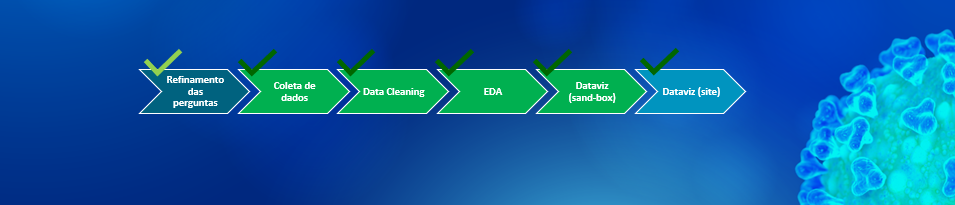

**Ferramentas**  
Para executar o método proposto elegemos as seguintes ferramentas para o projeto:

- Github: Código fonte
- Python: Linguagem de programação utilizada
- Matplotlib: Bibliotecas para visualização de dados
- Microsoft PowerBI: Para elaboração das visualizações sand-box
- Microsoft Teams: Documentação, reuniões e colaboração
- OBS Studio: Criação do vídeo de apresentação
- Youtube: Publicação dos vídeos do projeto

## 4. Resultados

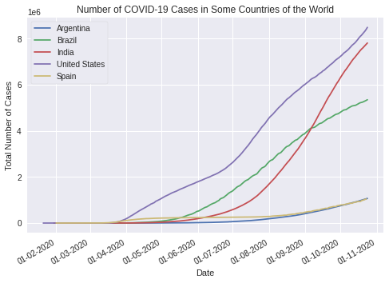

```python
import sys
import dask
import numpy as np
import pandas as pd

import holoviews as hv

import hvplot.pandas
import geoviews.tile_sources as gts

pd.options.display.max_columns = 10
hv.extension('bokeh', width=80)




#Total Cases
countries = ['Argentina','Brazil','India','United States','Spain']

# Time Series

plt.style.use('seaborn')

for country in countries:

	df_rem = df.loc[(df['location']==country)]
	date = df_rem['date']
	total_cases = df_rem['total_cases']
	plt.plot(date, total_cases, linestyle='solid', label=country)

plt.gcf().autofmt_xdate()
date_format = mpl_dates.DateFormatter('%d-%m-%Y')
plt.gca().xaxis.set_major_formatter(date_format)

plt.title('Number of COVID-19 Cases in Some Countries of the World')
plt.xlabel('Date')
plt.ylabel('Total Number of Cases')
plt.legend(framealpha=1, frameon=True);
plt.show()
```

[figure not shown]

```python
# Correlation

df_rem = df.loc[(df['location']=='Brazil')]
columns = ['total_cases','new_cases','total_deaths','total_cases_per_million','new_cases_per_million','total_deaths_per_million','total_deaths_per_million','total_tests','population_density','population_density','aged_70_older','cardiovasc_death_rate','female_smokers','male_smokers','diabetes_prevalence']
corr = df_rem.corr()
sn.heatmap(corr, annot=True)
plt.xticks(rotation=45)
plt.yticks(fontsize=6)
plt.xticks(fontsize=6)
plt.show()
```

## 5. Conclusão

Neste trabalho buscou-se abordar visualizações de dados complementares aos já disponiveis no domínio público trazendo um olhar para questões que ainda carecem de maior visibilidade por parte da população. Análise complementares podem ser exploradas com a mesma base para responder outras questões de interesse amplo e a medida que novas informações forem disponibilizadas por demais fontes de dados públicas.

Agradecemos a oportunidade dada pela prof. Dra. Raquel Minardi por explorar um tema de relevância global em sua disciplina cujo valor no contexto de Transformação Digital se encontra cada vez mais necessária para compreendermos o mundo com dados.